# 保育料無償化に関するアンケート調査

安藤道人（立教大学） 前田正子 (甲南大学)

2019-12-25 (Version 1）

# 1 アンケートの背景・目的

2019年10月から始まった「[幼児教育・保育の無償化](https://www.youhomushouka.go.jp/)」については、様々な意見がメディアや有識者の間で交わされている。一方で、その当事者である子育て世帯の声は断片的にしか伝わってこない。

そこで私たちは、ある自治体（以下A市）の協力の下で、「幼児教育・保育の無償化」の実施後のはじめての保育所入所申請世帯を対象にウェブアンケート調査を行い、その結果を集計した。

# 2 アンケートの概要

2019年11月に、A市の協力の下、A市の2020年度の認可保育所の入所申請のために市役所の窓口を訪れた全世帯に対して、保育料無償化についてのウェブアンケートの依頼用紙を配布した。この依頼用紙には、ウェブアンケートにアクセスできるQRコードおよび短縮URLが記載されており、保護者にスマートフォンあるいはパソコンでの回答を依頼した。

なお本アンケートの実施主体は、A市ではなく私たち研究者（安藤および前田）である。

アンケートフォームは、入所申請の対象となった子どもの年齢・月齢、申請世帯の子供の数、保育料無償化と保育所入所申請との関係、支払ってもよい保育料の額、保育料の無償化についての感想、母親や父親の働き方や年齢、そして世帯年収などの全18の質問を選択式で答える形式となっており、最後に自由記述欄も設けた。

各質問および回答選択肢については下記の集計結果を参照されたい。

# 3 アンケートの回答率および留意点

A市の特定化を避けるために正確な回答率は公開できないが、229人から回答を得て、約20%の回答率であった。

なお問18の回答分布によると、回答者には比較的高所得世帯が多い。これは、もともとA市の所得水準が高いことに加え、回答者がアンケート対象者の中の高所得世帯に偏っている可能性を示唆していてる。

本アンケートの回答率は約20%であり、本調査は、日本全体の保育所入所申請世帯の代表性という観点からも、A市の保育所入所申請世帯の代表性という観点からも、限界がある点に注意する必要がある。一方で、入所申請のために市役所の窓口を訪れた全世帯に対してアンケート案内の配布しているため、A市の入所申請世帯の特定の層がアンケート対象から外れているという懸念は少ない。

# 4 新規の入所申請か転園希望申請か

新規の申請が約78%、転園希望が約22%であった。

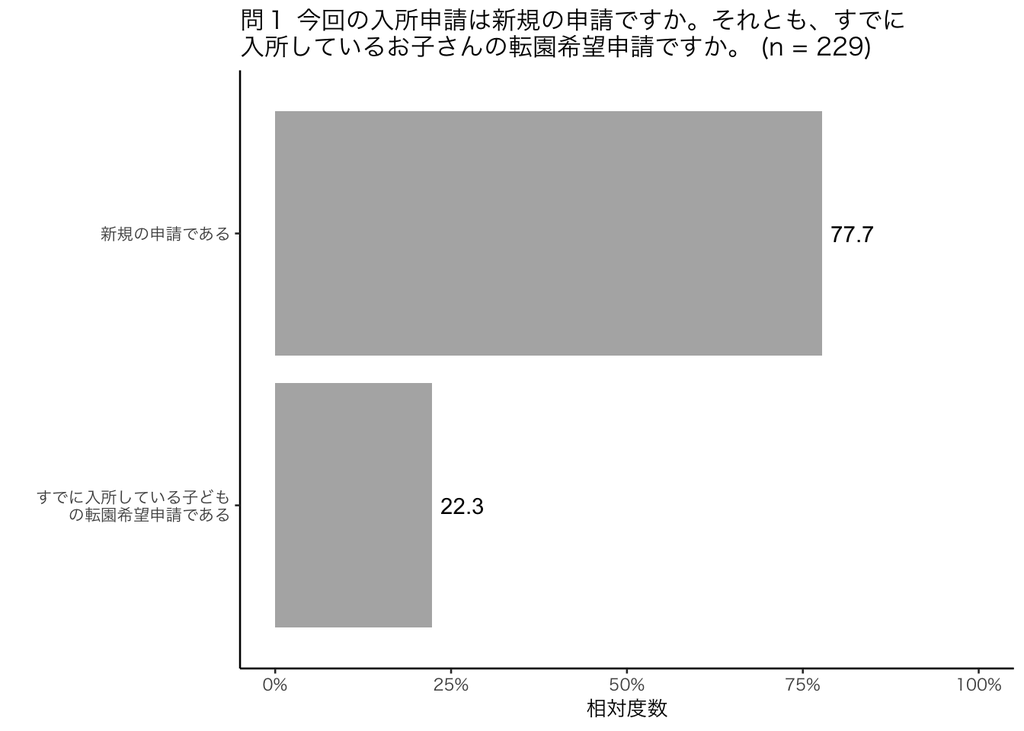

# 5 入所申請する子供の生まれ年

保育所入所を申請した子どもは、2019年生まれが最も多く約45%、その次が2018年生まれで約28%であった。

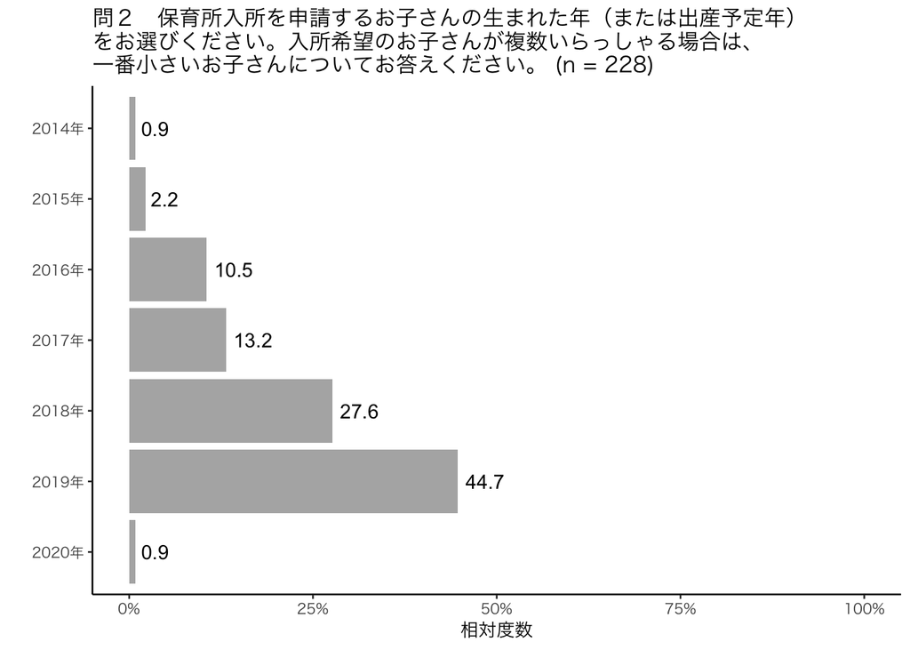

# 6 入所申請する子どもの生まれ月

保育所入所を申請する子どもの生まれ月については、最も多いのが約12%で5月生まれであり、最も少ないの約4%で2月生まれであった。

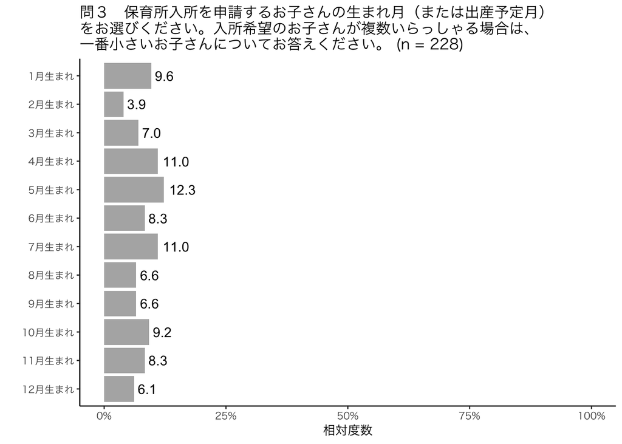

# 7 子どもの数

子どもの数は、最も多いのは１人で約62%、その次が2人で約33%であった。

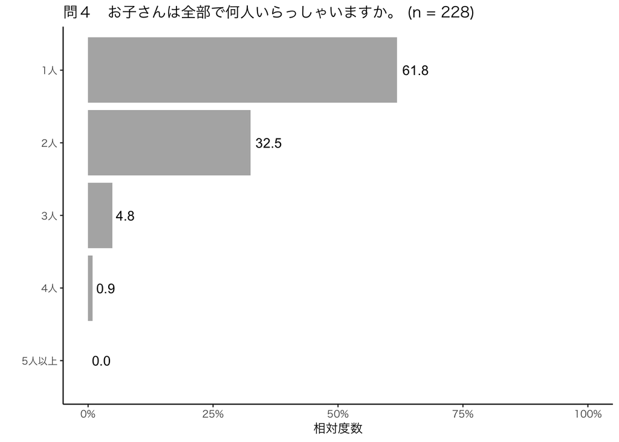

# 8 未就学の子どもの数（2020年4月時点）

2020年4月時点で未就学(小学校入学前)の子どもの数は、最も多いのは１人で約74%、その次が2人で約25%であった。

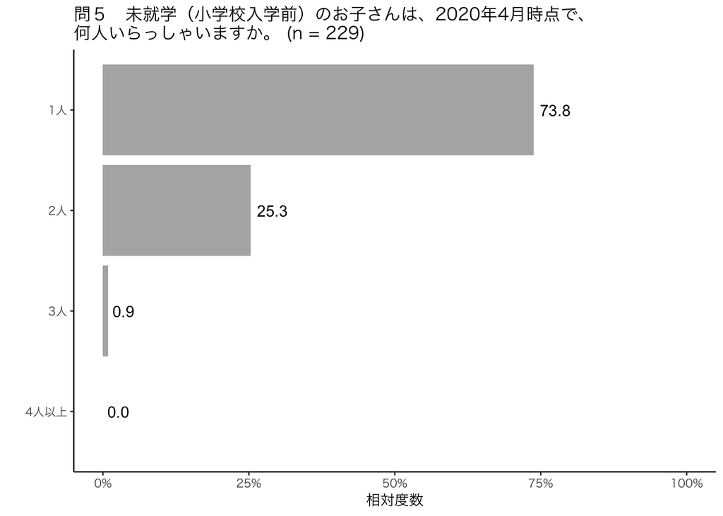

# 9 保育料無償化と保育所申請

保育所申請が保育料無償化がきっかけであるかという問いについて、約87%が「そう思わない」と回答した。

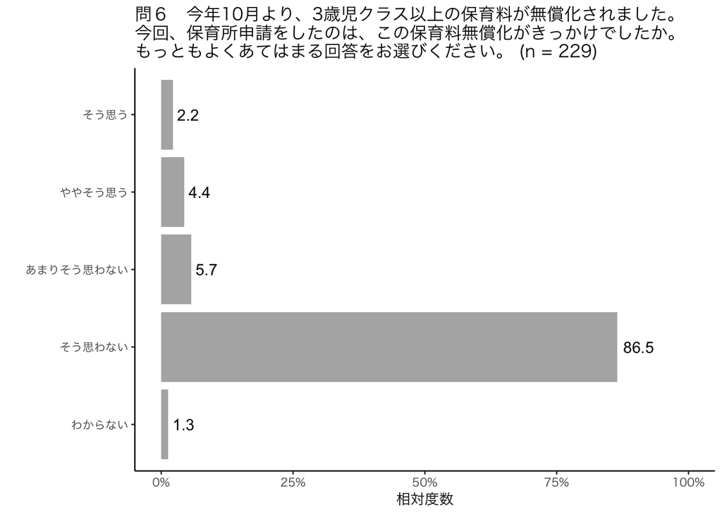

# 10 保育所入所のために支払ってよい保育料

認可保育所に支払っても良い保育料の最高額は、もっとも多いのは30,000円で約29%、次は50,000円で約21%であった。

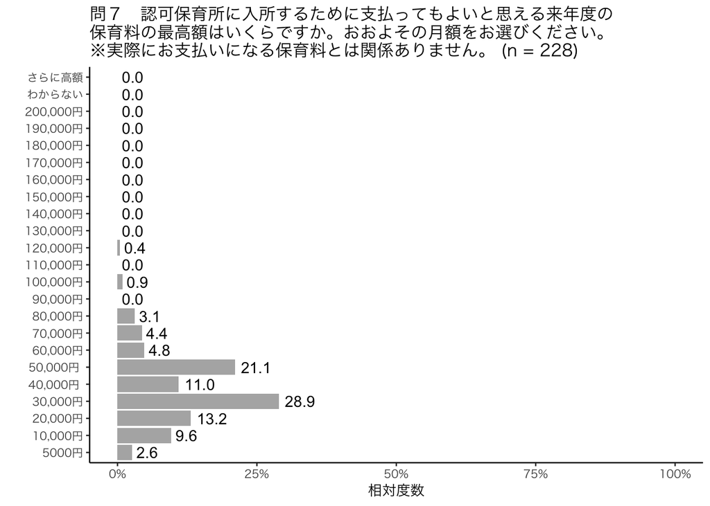

# 11 保育料無償化と出産希望

保育料の無償化政策により、より多くの子どもを産み育てたいかという問いに対して、最も多いのは「あまり思わない」で約31%、次に「思わない」が約27%であった。一方「思う」と「やや思う」はそれぞれ約13%と約26%であった。

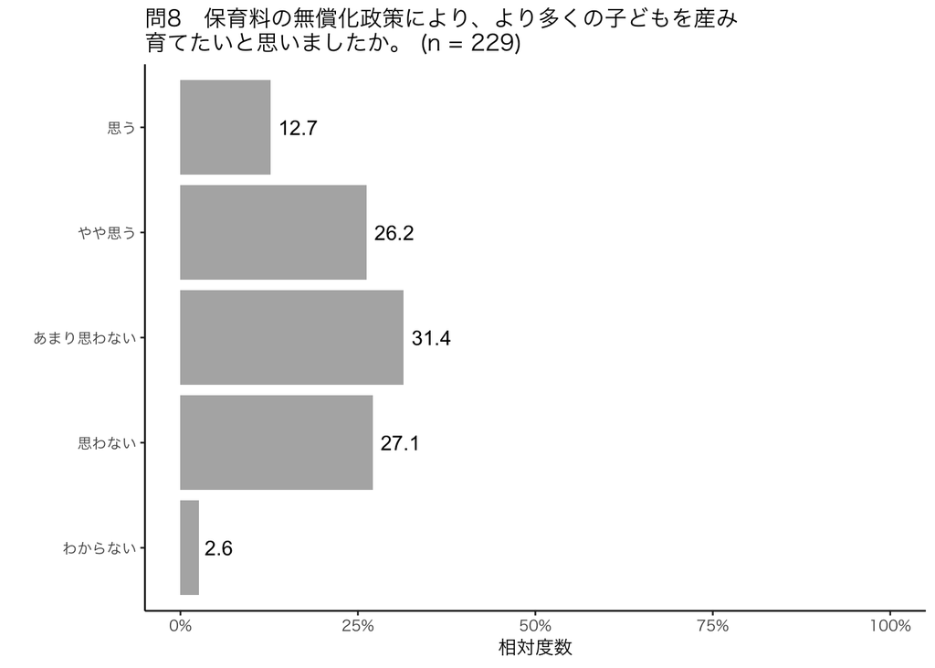

# 12 保育料無償化と幼稚園・保育園選択

3-5歳児クラスに入所申請をした世帯において、保育料無償化によって、幼稚園ではなく保育園に子どもを預けようとしたかという問いに対して、約79%が「そのとおりではない」と回答した。

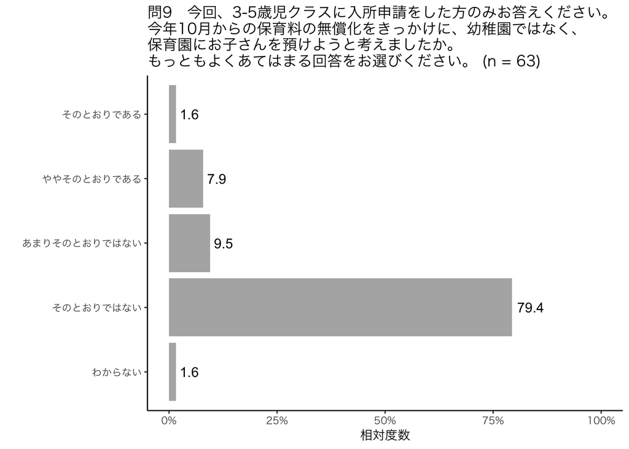

# 13 保育料無償化についての感想（不安、希望、疑問など）

保育料の無償化に対する感想として、最も多くの回答者が「あてはまる」と答えたのは、「無償化よりも保育士の待遇を改善するべきだった」であり、約63%であった。その他、「希望する認可保育園に入りにくくなりそう」、「無償化より保育園を増やすべきだった」もそれぞれ約62％、約58%であった。また、「子育ての経済的負担が 減りそう」も約50％であった。

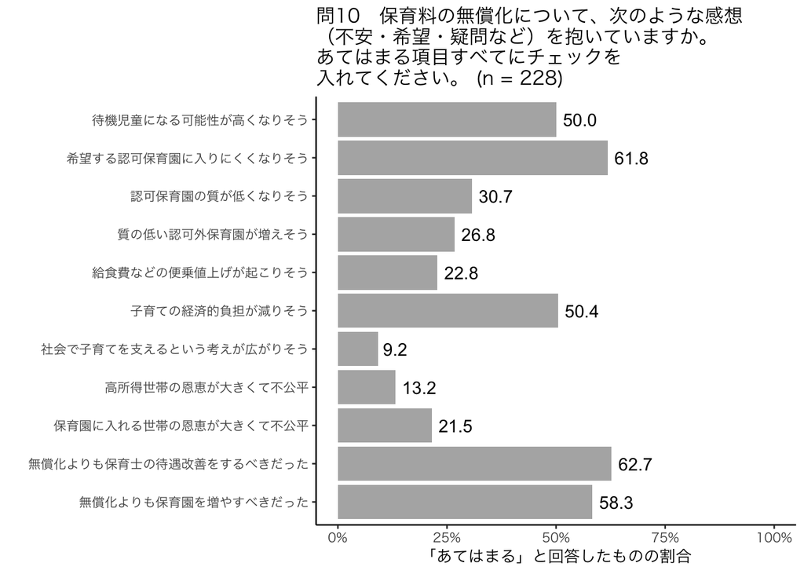

# 14 母親の現在の就労状況

母親の現在の就労状況で最も多いのは就労(常勤)で約46%、次が産前産後・育児休業中で約38%であった。

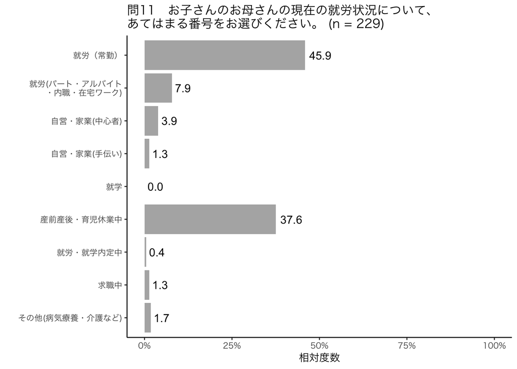

# 15 母親の来年の4月時点での就労予定

母親の来年の4月時点（つまり保育園入所開始時期）での就労の予定で最も多いのは就労(常勤)で約76%であった。パート勤務は約10％であり、産前産後・育児休業中は約5%であった。

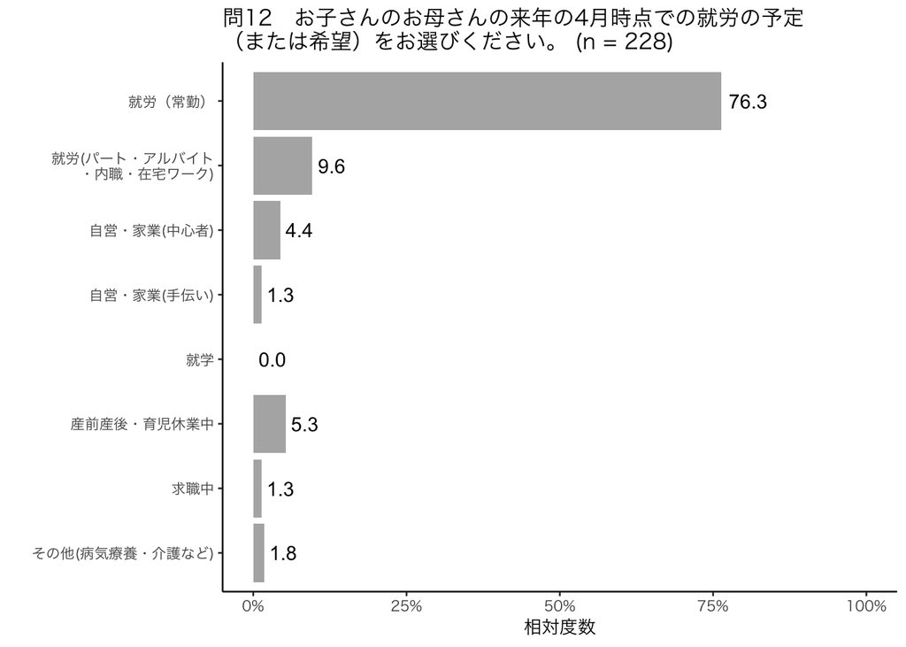

# 16 現在（2019年）の母親の収入や働き方

今年(2019年1〜12月)の母親の収入や働き方で最も多いのは「年収は200万円以上となる予定である」で約36%、その次に「収入はない予定である」で約28%であった。

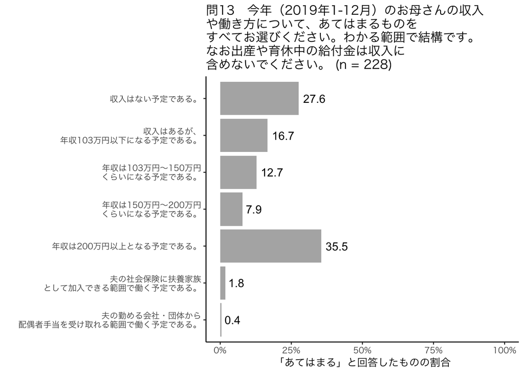

# 17 来年の4月以降の母親の収入や働き方（保育所に入所した場合）

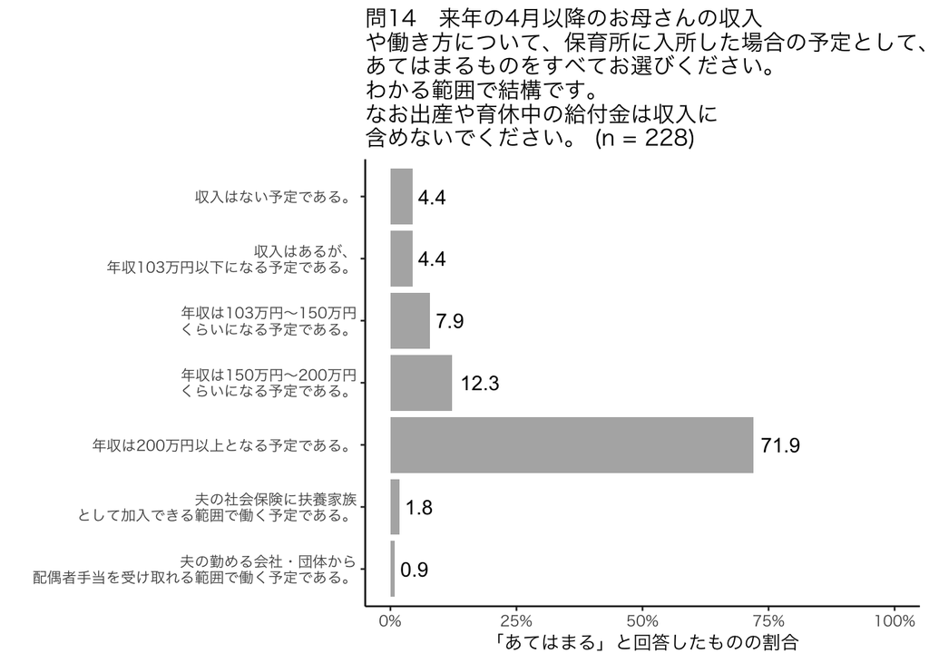

# 18 母親の年齢

お子さんのお母さんの年齢で最も多いのは、「30-34歳」と「35-39歳」であり、それぞれ約37%であった。

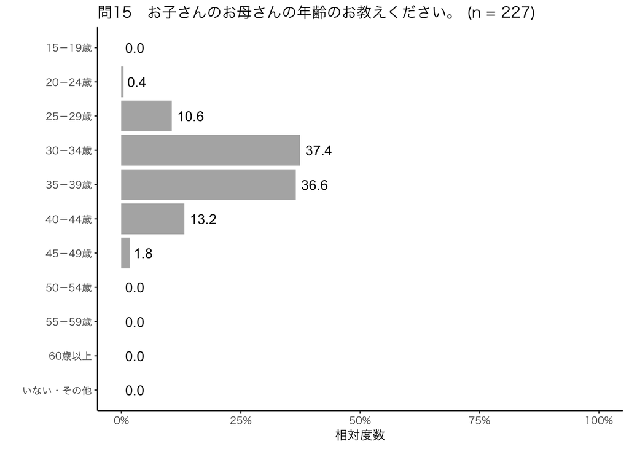

# 19 父親の年齢

子どもの父親の年齢で最も多いのは「35-39歳」で約36%であり、その次が「30-34歳」で約29%であった。

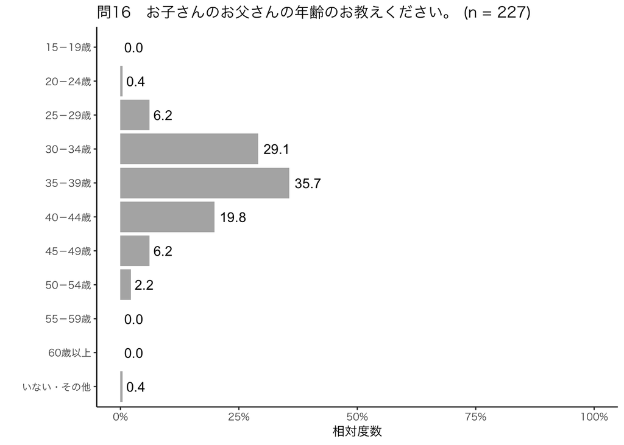

# 20 父親の現在の就労状況

父親の現在の就労状況で最も多いのは、就労（常勤）で約92%であった。

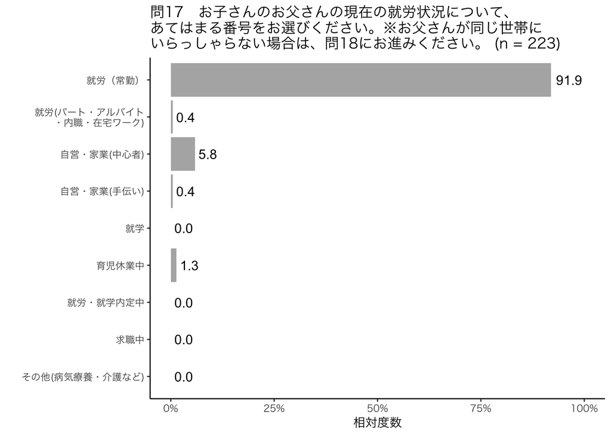

# 21 2019年1月-12月の世帯の合計年収の見込み額

2019年1月-12月の世帯の合計年収の見込み額は「700-800万円未満」が約15%であり、「500-600万円未満」と「600-700万円未満」が約14%であった。

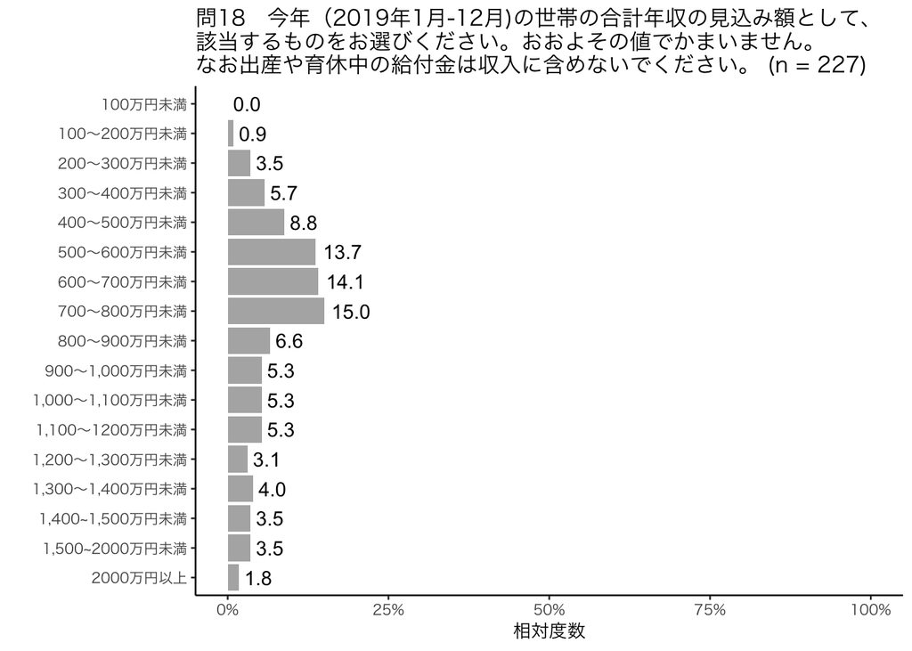

※なおアンケート開始当初は「なお出産や育休中の給付金は収入に含めないでください」との文言は欠落しており、回答数が60の時点で追加修正している。

# 22 幼児教育・保育の無償化についての意見・感想

以下では回答者の自由記述を掲載している（一部の自由記述は掲載していない）。

| comments |
| --- |
| 無償化にこだわるよりかは保育士の収入を上げ、より質の高い保育士を増やし、安心して預けられる保育園を増やしてもらえると働く親としては助かります。保育園が無償化になったとしても出生率は上がらないと思います。 |
| 0〜2歳も無償化の対象にするべきだと思います |
| 3歳クラスへの入りにくさが増すような気がするのが心配です（2歳までの園に預けていたので、保活をしています） |
| 無償化といっても3歳児以上で、まだあまり実感がありません。ただ、認可に入れる人と入れない人の格差がますます広がるのではと懸念しています。まずは、保育園の全入を目指して、フルタイム勤務でなくても、正社員でなくても、働きたい母親が働きたい時に働けるようにすることが求められていると思います。 |
| 保育士の給料をあげて保育士の数を増やすべきだった。無償化は助かるが根本的には意味がない。 |
| 無償化により、保育園の入園希望者が増加し、その結果として待機児童数が増加することを懸念。保育園に預けたい保護者は、保育料を支払ってでも復職したいと考える者もおり、もっと多くの者の意見を汲むべきだった。 |
| 無償化にするなら、いっそのこと義務教育にした方がよいのではないか。（幼稚園か保育園かは選択できるとして） |
| 無償化は、子育てに国が力を入れ始めた証でもあり大変有難く思っています。一方、根本的な問題である、保育の担い手たる保育士の待遇改善無くしては、保育現場は疲弊し、持続不可能となります。この点を是非改善頂きたいです。 |
| 無償化を０歳から行って欲しいが、保育士さんの待遇が良くなったほうが保育園の質がよくなりそうだと思いました。 |
| 是非、0歳から無償にして頂きたいです。育休から復帰する人は、2歳までに保育園に入れる人が殆どだからです。3歳まで子育て世帯か経済的にも体力的にも大変なのは変わりません。 |
| 認可保育園に関してはすでに年収に応じて料金が決まる等の措置が取られているので、これ以上しなくてもと思っています。勿論無償化はありがたいですが、希望園に通えない事や日頃の先生方の大変さを思うとそちらを解消するのが先だったと思います。 |
| 反対です。質の良い保育のためには適切な保育料を支払うべきですし、保育士さんたちの収入を上げ地位を上げて頂くことを優先して欲しいです。それが質の担保になると思います。非常に頓珍漢な施策だと思っております。 |
| 無償化は必要なかったと思います。それよりも、保育士の処遇改善が優先です。 |
| 私は週に4日9〜16時まで仕事のため、14時以降は幼稚園の延長保育を利用しています。無償化のおかげで延長保育代も補助されるようになったのでありがたく思っています。ですが月に48時間以上就労していれば、延長保育代が補助されるそうですが、幼稚園に通わせながら働いている母親は幼稚園の定時である9〜14時の間で働いてる方が多数です。実際に14時以降も働いて延長を利用している方は少数です。幼稚園に預けている… |
| 待機児童ゼロにしてほしいです |
| 0-2歳児についても検討していただきたいです。直接保育料の減額でなくとも、施設の拡充や保育士さんの待遇改善といった実質的な値下げということでもいいのではないかと思います。 |
| 無償化にすべきではなかったとおもいます。その料金で保育士のお給料を上げて保育士の人数を増やし認可園も増やす方がよかったと思います。 |
| 駅から近い保育園の新設や小規模保育園の5歳までの預かり延長などを優先してほしかったです。また、保育士さんの待遇改善もお願いしたいです。 |
| 有償でよいので、施設の数を増やし待機児を減らすことを優先させてほしい。 |
| 無償化はありがたい反面、未だに待機児童が多い地域にとっては、格差の広がりなどが懸念されます。まず、希望する人が保育園に漏れなく入れる状況を作ってから無償化すべきだと今でも思います。今回の政策は順番を間違えているのでは？と声を大にして言いたいです。 |
| 今後ますます歳出が増えていく見込みなのに、無償化に費用を投じる必要性は全く感じません |
| 色々改善点はあるかと思いますが、大変感謝しております。ただやるなら負担の多い0、1歳児を全世帯無償化にしてほしかったです。 |
| 0歳児から無償化を希望 |
| 乳児のほうがよりお金がかかるので乳児クラスの保育の無償化も必要だと思う。経済的理由で、現状では子供をたくさん産みたいとは思えない。 |
| 今年第1子を出産、育休が取得できず早期復職を予定しているが、年度途中での入園ができず待機児童となっている。復職できず育休手当もないため生活が困窮しているが、保育園入園の加点など救済措置はない。そのため無償化は、現時点の自分にとってなんのメリットもなく、少子化対策と言えるものではない。 |
| 保育の質を担保してほしい |
| 上の子どもたちは公立認可保育園に入ってました。一番下の子どもは民間の小規模にしか入れず行っていますが、保育の質、レベルが全く違い、公立保育園を経験してしまうと、通えない。しかも園長が年度途中で退職なんて、信頼できない。しかし別の保育園には入れない。であれば、多少お金を払ってでもまともな保育園に通わせたい。 |
| 保育の質が下がらないようにして欲しい。また給食費などの便乗値上げはやめて欲しいです。 |
| 無償化より、認可保育園の数が足りない。 |
| 現場のニーズとは異なった全く意味のない政策だと思う |
| 無償化もありがたいが、それ以上に認可保育園への入りやすさを改善していただきたい。もう1年育児休業を取りたかったが、少しでも保育園に入りやすい0歳児入園にせざるを得なかったため。 |
| 3歳以下もぜひ無償化を進めてほしい。 |
| 10月からスタートしたにもかかわらず、認可外保育所に通っている児童にいくらの補助がでるのか現時点でも明確になっていない。 |
| 無償化の必要はない。負担はするべきだと思う。無償化ではなく、その分保育園の数を増やす、保育時間を延長する、病児保育園を増やす、障害児保育の拡充など、保育に関する問題を改善する方に費やして欲しい。 |
| 無償化以前に保育園が全く足りず入所できない。政府と行政、そして議員への怒りしかない。 |
| 個人的には無償化、非常に助かります。この分のお金が保育園の先生のお給料アップにつながればいいなと思います。 |
| 共働き世帯が増えている中で、無償化が3歳からなのが不思議。育児休業が延長できない会社に務めている人は、是が非でも保育園に入れなければ仕事を辞めざるを得ないことを考えると、保育園の無償化もしくは施設を増やすことも今後の政策に加えてほしい。 |
| 無償化ではなく待機児童をなくして欲しいし、保育士への手当てを増やすなどして受け入れ側の人手を増やしてほしい。希望すれば入れるようになったらいいと思う。 |
| 保育園の運営や給食の質を維持出来るのか心配。無償化になったことで悪化するならこれまで通り保育料を支払いたいと思う。 |
| 保育園無償化についてスタートしました、はいそれで終わり、ではなく、やっていく中で来年、再来年、その先の子育て世代にとって、より良い制度となるように反省・改善・更新していって欲しいです。 |
| 対象年齢を0,1,2,3と拡大した上で、入所できる人数を増やして、入所できる働き方を拡大すれば、もっと預けて働く人が増え人手不足の解消に繋がると思います。 |
| 保育料は無償化になっても、外出しされる教材費等で実質負担増だと聞く。そこを解消してほしい。また、保育士増加、園増加に対して施策をとってほしい。 |
| 2歳児以下の保育料無償化をご検討頂きたくお願いします。 |
| 3歳以上の無償化より、0から2歳の産後の収入が安定しない時期の保育無償化の方がありがたいと思う |
| 0歳から3歳までも無償化してください。保育園に入所できない際の一時保育やベビーシッターも無償化して下さい。今しはらっています。年収が高い人は無償化する必要ないでしょう。 |
| 保育の質をもっと高めて欲しい。その分、保育者に方がやりがいを感じられる対応をお願いしたい。テレビで報道されるような親が見ていないところでの子どもを放置、怪我をさせる、罵声を浴びせる等の行いがないよう勤めていただきたい。 |
| 既に入所できている3歳以降の保育園児の無償化は不公平と感じる。無償化より希望者が全員入所できるようにすべき。 |
| 0〜2歳の方が保育料が高いので、そちらの無償化、軽減を望みます。 |
| 待機児童になってしまう人にとっては、嬉しくないと思う。幼稚園の便乗値上げも予測できたはず。違うやり方もあったのではないか。 |
| 保育の質低下が憂慮されたり、また待機児童削減や保育士の待遇改善やなり手確保が先にすべきという反対意見も有識者から多く提言されているにも関わらず、なぜ強行したのか意味がわからない。国民を馬鹿にするのもいい加減にしてほしい。 |
| 少子化対策と女性活躍を狙ったものと聞いているが、的外れとしか思えない。予算があるなら、そもそもの保育園や先生の数を増やす。更には、遅い時間や土日まで預かれる施設を拡充するなど、親(特に母)が制約なく働ける環境整備に使って欲しかった。１人目の子供の時、最寄りの認可保育園ではお迎えの時間の関係でフルでは働けないため、認可外を選んだ。無償化で軽減される経済的負担は一時的なもの。思うように働けて、将来につ… |
| 無償化は嬉しいけれど、それより保育士の数を増やすための対策が先だと思う。保育士の数が少なければ、無償化になって預けたい人が増えても、結局預けられない。 |
| 無償化は家計にとっては助かりますが、保育の質の低下と貧富の格差の拡大を懸念しています。無償化するのではなく、保育の質の向上に予算を当てるべきと考えます。 |
| 通える認可は全落ちし、短時間保育認定者（1日7時間以内かな）用の施設（小規模保育施設）に預けてほぼフルタイム勤務をしているため、延長保育分については支払いが発生している。認可園であれば通常保育時間内なので、全額無償になるのに、認可に入れなかったことが原因でうちは支払いが発生するのは不公平。認可園の方が保育が手厚かったり、配置基準が厳しかったりして、質のよい保育体制が敷かれているのに。ますます認可に… |
| 家計が厳しいのでとても助かります。 |
| パートであれ常勤であれ保育園にもっと入りやすくしてほしい 倍率が高過ぎる |
| 0歳児からの保育料負担軽減が早く実現することを切に願います。育児にかかる費用はかなり負担になることがよくわかりましました。 |
| 自宅に近い場所にみんなが入れるのが理想。 |
| 無償化されたことは、とても子供がいる世帯としては有り難かった。ただ、保育園は増えてはきているが、短期間に増やすことが重視されたせいで、園庭もなく狭い園や環境が良くない園も多い。お給料も安いので、若い先生が多く、辞めてしまう人もいて、ベテランの安心感のある職員は少ない印象。今後は職員の待遇改善や保育環境など、質をもっと考えてほしい。保護者にとって大切な子供を「預けられればよし。」とは思っていない。今… |
| 保育園が足りません。 |
| 自宅に近い場所にみんなが入れるのが理想。 |
| 3歳以降だけでなく、0歳児保育にもある程度の補助が必要だと思う。 |
| 無理に無償にしなくても、良いサービスが得られるなら有償でも良いと思う |
| 無償化はもちろんありがたいが、子供への費用がかかるのは当たり前なので無償でなく負担があっても、保育園へ従事する人材への還元拡大・人材確保・質の向上のあててほしかった。 |
| 日本は何故子供の数が過去最悪なのに待機児童は減らないのでしょうか？非常に矛盾していると思っています。子供を増やしたいのであれば、まず待機児童0にするのが先なのでは？無償化は非常に助かりますが、じゃあもう一人…となる訳がありません。 |
| 3歳以上が無償化になることは有り難いが、1歳児が入れる認可保育園がそもそも足りない。無償化の前に保育園を増やして欲しい。就労内定中だと点数が足りないのですぐ認可保育園に入れる可能性は限りなく低く、兄弟で別々の保育園になる可能性が高い。相当の覚悟をして復職しなければならない状況をもう少し改善して欲しい。一度仕事から離れたお母さんが、子供を保育園に預けてまた働きたいと思える世の中になればいいと思う。 |
| 無償化により、待機児童や兄弟別園の問題を優先させるべきです。 |
| 経済的負担軽減はとても有り難いですが、待機児童問題、保育士の低収入及び園の人員不足の解決が第一ではないかと考えます。働くお母さん、お父さんとしては、むしろお金は払うので、どこかで保育してもらえないか、という気持ちではないでしょうか？目先のお金という問題を解決するより、社会全体で(両親だけでなく)子育てができる方策を長期計画でも構わないので、少しずつ示してもらえたら希望が持てます。 |
| 待機児童がいなくなりますよう今後とも対策をお願いします。 |
| 保育園無償化をCMなどで宣伝していたが、実際には0歳など無償にならない部分が注釈でしか入っておらず、大きな誤解を招く広報の方法だと思った。大変不愉快でした。「一部保育無償化」などキャッチフレーズを変えて、全てが無償になる訳ではないことを広く広報すべき。 |
| 無償化では、保育園に入れなかった世帯の場合は入所できないうえ無償化の恩恵も受けられないため、その格差に疑問が残る。無償化よりも、保育園入所を希望するすべての子が保育園に入れるようにするにさどうしたらいいのかを考えてほしい。 |
| 保育園に入れたらとてもありがたい制度だけど、入れなかった場合は…？と考えてしまいます。フリーランスであったり様々な状況で保育園に入ることが不利で入れなかった人には微妙な制度だなと思います。保育園に入れた人より生活状況が大変なのに、無償化の恩恵が受けられない上に、稼ぐこともできず、両者で恩恵の差が出るのが惜しいところだなと思います。でも保育園に入れなくても、幼稚園に入ったら助成金があるので、それは助… |
| 保育園に入れている人はずっと得をするし、入れてない人はずっと不利。無償化しても入れてない側からすると無意味。待機児童を減らすのが先。幼稚園の預かり保育も完全無償化になるなら多少は良いが…。 |